# DSC-515 Predictive Modeling for Medical Costs

### Overview

This project focuses on predicting individual medical costs using linear regression models built from the Medical Cost Personal Dataset. This notebook will explore and prepare the data, engineer meaningful features, and apply multiple regression techniques, including baseline, Ridge, and Lasso, to evaluate model performance. Finally, this notebook will compare results, interpret feature importance, and discuss how these insights can support better decision‑making in health‑care settings.

#### Task 1. Data Processing and Feature Engineering

Load and explore the dataset, address missing values, summarize patterns with visuals and statistics, and note key observations and assumptions while identifying predictors from the medical cost distribution. Create and justify new features, and apply normalization or standardization only where needed based on model requirements.

#### Task 2. Modeling and Evaluation

Implement a baseline linear regression model using your selected features, split the data into training and testing sets, and compare it with Ridge and Lasso regression while evaluating each through residual checks, diagnostics, and performance metrics. Train the validated models, generate predictions, and assess results using measures such as RMSE, MAE, and R‑squared to guide your interpretation.

#### Task 3. Analysis and Interpretation

Compare model performance using tables and plots, noting any unexpected patterns or errors, and evaluate feature importance to determine which predictors most strongly influence medical cost estimates. Use these insights to recommend how health‑care providers can apply the predictions and key features to improve patient care and resource planning.

## Task 1. Data Processing and Feature Engineering

The dataset of interest is the Medical Cost Personal Datasets, which contains information about individuals' medical costs and various demographic and health-related features. This dataset will be the foundation for our predictive modeling efforts.

To begin, import the necessary Python packages for data exploration, visualization, and building regression models, as well as load the dataset into a Pandas DataFrame.

```python
# Import necessary packages
import numpy as np
import pandas as pd
import matplotlib.pyplot as plt
from matplotlib.pyplot import subplots
import kagglehub
from kagglehub import KaggleDatasetAdapter
from sklearn.model_selection import train_test_split
from sklearn.linear_model import LinearRegression
from sklearn.metrics import mean_squared_error, r2_score
from sklearn.linear_model import Ridge
from sklearn.linear_model import Lasso
```

```python
# Load the dataset directly (no file path needed)
path = kagglehub.dataset_download("mirichoi0218/insurance")

# Load the CSV
df_medical = pd.read_csv(path + "/insurance.csv")

# Display the first few rows of the dataset
print(df_medical.head())

# Check if data types are appropriate
print(df_medical.info()) # May need to convert boolean columns to numeric later
```

```
   age     sex     bmi  children smoker     region      charges
0   19  female  27.900         0    yes  southwest  16884.92400
1   18    male  33.770         1     no  southeast   1725.55230
2   28    male  33.000         3     no  southeast   4449.46200
3   33    male  22.705         0     no  northwest  21984.47061
4   32    male  28.880         0     no  northwest   3866.85520
<class 'pandas.core.frame.DataFrame'>
RangeIndex: 1338 entries, 0 to 1337
Data columns (total 7 columns):
 #   Column    Non-Null Count  Dtype
---  ------    --------------  -----
 0   age       1338 non-null   int64
 1   sex       1338 non-null   object
 2   bmi       1338 non-null   float64
 3   children  1338 non-null   int64
 4   smoker    1338 non-null   object
 5   region    1338 non-null   object
 6   charges   1338 non-null   float64
dtypes: float64(2), int64(2), object(3)
memory usage: 73.3+ KB
None
```

One pair of duplicate rows was identified and removed during the cleaning process. Although those could have been unique patient records, they were treated as duplicates for the sake of this analysis.

```python
# Check for duplicate rows
print(f"Before removing duplicates: {df_medical.shape[0]} rows")
df_medical.duplicated().any()  # 1 pair of duplicate rows found

# Save duplicate rows if any exist
duplicate_rows = df_medical[df_medical.duplicated(keep=False)]
print(f"Duplicate rows found:\n{duplicate_rows}")

# There appears to be one duplicate entry.
# Create a final dataframe without duplicates
df_medical_final = df_medical.drop_duplicates()

# Confirm removal of duplicates
print(f"After removing duplicates: {df_medical_final.shape[0]} rows")
```

```
Before removing duplicates: 1338 rows
Duplicate rows found:
     age   sex    bmi  children smoker     region    charges
195   19  male  30.59         0     no  northwest  1639.5631
581   19  male  30.59         0     no  northwest  1639.5631
After removing duplicates: 1337 rows
```

The final cleaning steps involves converting boolean columns to integers ('sex' and 'smoker'), and creating a new feature by converting the continuous age variable into categorical age‑range groups. These categories align with the World Health Organization’s (WHO) adult age‑classification framework, which defines major life‑stage groups such as young adults (25–44), middle‑aged adults (44–60), and older adults (60+). Using WHO‑based groupings provides a standardized, globally recognized structure for demographic analysis and supports clearer interpretation in predictive modeling.

```python
# Convert 'sex' and 'smoker' to numeric data types.
df_medical_final['sex'] = df_medical_final['sex'].replace({'male': 1, 'female': 0}).astype(int)
df_medical_final['smoker'] = df_medical_final['smoker'].replace({'yes': 1, 'no': 0}).astype(int)
# Check the updated data types
print(df_medical_final.dtypes[['sex', 'smoker']])

# Convert 'age' to ranges based on WHO adult age classifications.
age_bins = [18, 25, 45, 60, 100]
age_labels = ['18-24', '25-44', '45-59', '60+']

df_medical_final.loc[:, 'age_group'] = pd.cut(
    df_medical_final['age'],
    bins=age_bins,
    labels=age_labels,
    right=False
)

# Check the new 'age_group' feature.
print(df_medical_final.loc[:, ['age', 'age_group']].head(10))

# Check the distribution of the new 'age_group' feature.
print(df_medical_final.loc[:, 'age_group'].value_counts())
```

```
sex       int64
smoker    int64
dtype: object
   age age_group
0   19     18-24
1   18     18-24
2   28     25-44
3   33     25-44
4   32     25-44
5   31     25-44
6   46     45-59
7   37     25-44
8   37     25-44
9   60       60+
age_group
25-44    531
45-59    415
18-24    277
60+      114
Name: count, dtype: int64
```

'Age', 'sex', 'bmi', 'children', and 'charges' are numeric features in the dataset. Although the description of 'charges' is somewhat vague, this variable represents the individual medical costs we aim to predict. Individuals range from 18 to 64 years old, with a mean age of about 39. 'Bmi' spans roughly 16 to 53 and shows moderate right skew, while 'charges' display substantial variability and a strong right skew due to a small number of high‑cost cases. The number of 'children' is generally low, with most individuals reporting 0 to 2 children.

```python
# Summary statistics for numerical columns.
print(df_medical_final.describe())

# Do men or women have more children on average?
avg_children_by_sex = df_medical_final.groupby('sex')['children'].mean()
print(f"Average number of children by sex:\n{avg_children_by_sex}")
```

```
               age          sex          bmi     children       smoker  \
count  1337.000000  1337.000000  1337.000000  1337.000000  1337.000000
mean     39.222139     0.504862    30.663452     1.095737     0.204936
std      14.044333     0.500163     6.100468     1.205571     0.403806
min      18.000000     0.000000    15.960000     0.000000     0.000000
25%      27.000000     0.000000    26.290000     0.000000     0.000000
50%      39.000000     1.000000    30.400000     1.000000     0.000000
75%      51.000000     1.000000    34.700000     2.000000     0.000000
max      64.000000     1.000000    53.130000     5.000000     1.000000

            charges
count   1337.000000
mean   13279.121487
std    12110.359656
min     1121.873900
25%     4746.344000
50%     9386.161300
75%    16657.717450
max    63770.428010
Average number of children by sex:
sex
0    1.074018
1    1.117037
Name: children, dtype: float64
```

```python
# Summary statistics for categorical columns.
print(df_medical_final.describe(include=['object']))

# What are all unique values for region?
print(df_medical_final['region'].unique())
```

```
           region
count        1337
unique          4
top     southeast
freq          364
['southwest' 'southeast' 'northwest' 'northeast']
```

Next, we review the distribution of the target variable, charges, to assess its skewness and identify any potential outliers. The numerical summary shows that charges are right‑skewed, as the mean is noticeably higher than the median. This pattern indicates that a small subset of individuals incur exceptionally high medical costs, creating a long upper tail and potential outliers. The histogram below will further illustrate this skewed distribution.

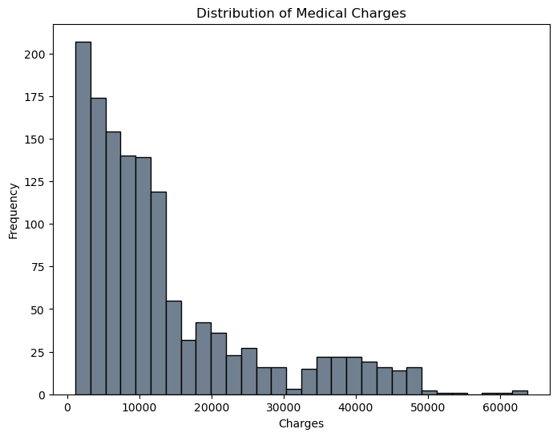

```python
# Plot histogram of charges
fig, ax = subplots(figsize=(8, 6))
ax.hist(df_medical_final.loc[:, 'charges'], bins=30, color='slategray', edgecolor='black')
ax.set_title('Distribution of Medical Charges')
ax.set_xlabel('Charges')
ax.set_ylabel('Frequency')
plt.show()
```

```python
# Compute correlation matrix for numerical features.
df_medical_final.info()  # Confirm which columns are numeric

# Compute correlation matrix for numeric features only
print(df_medical_final.select_dtypes(include='number').corr())
```

```
<class 'pandas.core.frame.DataFrame'>
Index: 1337 entries, 0 to 1337
Data columns (total 8 columns):
 #   Column     Non-Null Count  Dtype
---  ------     --------------  -----
 0   age        1337 non-null   int64
 1   sex        1337 non-null   int64
 2   bmi        1337 non-null   float64
 3   children   1337 non-null   int64
 4   smoker     1337 non-null   int64
 5   region     1337 non-null   object
 6   charges    1337 non-null   float64
 7   age_group  1337 non-null   category
dtypes: category(1), float64(2), int64(4), object(1)
memory usage: 85.1+ KB
               age       sex       bmi  children    smoker   charges
age       1.000000 -0.019814  0.109344  0.041536 -0.025587  0.298308
sex      -0.019814  1.000000  0.046397  0.017848  0.076596  0.058044
bmi       0.109344  0.046397  1.000000  0.012755  0.003746  0.198401
children  0.041536  0.017848  0.012755  1.000000  0.007331  0.067389
smoker   -0.025587  0.076596  0.003746  0.007331  1.000000  0.787234
charges   0.298308  0.058044  0.198401  0.067389  0.787234  1.000000
```

## Task 2. Modeling and Evaluation

The next task will initiate the modeling process, implementing a baseline linear regression model using the predictor features selected during Task 1. These predictors were chosen based on their correlation with the target variable. After defining the feature matrix predictors (X) and the target feature (y), the dataset was split into training and testing subsets to ensure that model performance could be evaluated on unseen data. This split provides a fair assessment of how well the baseline model generalizes beyond the training sample.

```python
# Define X and y
X = df_medical_final[['age', 'bmi', 'sex', 'smoker']]
y = df_medical_final['charges']

# Split the data into training and testing sets
X_train, X_test, y_train, y_test = train_test_split(
    X,
    y,
    test_size=0.2,
    random_state=42   # Research suggests using 42 as a standard random state for reproducibility
)

# Test the sizes of the splits
print(f"X_train shape: {X_train.shape}, y_train shape: {y_train.shape}")
print(f"X_test shape: {X_test.shape}, y_test shape: {y_test.shape}")

# Baseline Linear Regression Model
baseline_model = LinearRegression()
baseline_model.fit(X_train, y_train)

# Evaluate baseline model performance
y_pred = baseline_model.predict(X_test)
mse_baseline = mean_squared_error(y_test, y_pred)
r2_baseline = r2_score(y_test, y_pred)
print(f"Baseline Linear Regression Model - MSE: {mse_baseline}, R²: {r2_baseline}")
```

```
X_train shape: (1069, 4), y_train shape: (1069,)
X_test shape: (268, 4), y_test shape: (268,)
Baseline Linear Regression Model - MSE: 35833764.88837129, R²: 0.8049927490808868
```

Ridge Regression (L2) is a regularization technique that adds a penalty equal to the square of the magnitude of coefficients to the loss function. This approach helps prevent overfitting by shrinking the coefficients of less important features, leading to a more generalized model. Ridge Regression is particularly useful when dealing with multicollinearity among predictors, as it can stabilize coefficient estimates. A common disadvantage of Ridge Regression is that it may not perform well when the true relationship between the features and the target variable is highly nonlinear.

The L2 produced an R² of 0.80 and an MSE of roughly 36 million, showing that it explains a substantial portion of the variance in medical charges while maintaining prediction errors comparable to the baseline model. The predictions fall within a reasonable range, suggesting that the L2 penalty helped control coefficient magnitude without decreasing overall accuracy. These results show that Ridge provided a more regularized and reliable version of linear regression, particularly useful given the variability and skewness of medical‑cost data.

```python
ridge_model = Ridge(alpha=1.0)

# Fit the model on the training data.
ridge_model.fit(X_train, y_train)

# Predictions on the test set.
y_pred = ridge_model.predict(X_test)
print(f"Ridge Regression Predictions:\n{y_pred[:10]}")

# Evaluate the Ridge Regression model
mse_ridge = mean_squared_error(y_test, y_pred)
r2_ridge = r2_score(y_test, y_pred)
print(f"Ridge Regression Mean Squared Error: {mse_ridge:.2f}")
print(f"Ridge Regression R^2 Score: {r2_ridge:.2f}")
```

```
Ridge Regression Predictions:
[ 8418.64590989  4402.48784717 13227.6037824  30458.14605774
  8730.07482282 12991.36541772 29216.26772522  2244.5242447
 10987.24020306 10301.70979524]
Ridge Regression Mean Squared Error: 36003429.81
Ridge Regression R^2 Score: 0.80
```

Lasso Regression (L1) is another regularization technique that adds a penalty equal to the absolute value of the magnitude of coefficients to the loss function. This approach can lead to sparse models where some feature coefficients are exactly zero, effectively performing feature selection. Lasso Regression is particularly useful when we suspect that many features are irrelevant or when we want a more interpretable model. However, a potential drawback is that it may not perform well when the true relationship is complex and involves many small effects.

In this analysis, the Lasso model achieved an MSE of 35,834,592 and an R² of 0.805, indicating that it explained about 80% of the variance in the outcome. These results show that the model generalized well to unseen data and maintained stability in its predictions, reflecting the balance Lasso strikes between model simplicity and predictive accuracy.

```python
lasso_model = Lasso(alpha=0.1)

# Fit the model on the training data.
lasso_model.fit(X_train, y_train)

# Predictions on the test set.
y_pred = lasso_model.predict(X_test)
print(f"Lasso Regression Predictions:\n{y_pred[:10]}")

# Evaluate Lasso model performance
mse_lasso = mean_squared_error(y_test, y_pred)
r2_lasso = r2_score(y_test, y_pred)
print(f"Lasso Regression Model - MSE: {mse_lasso}, R²: {r2_lasso}")
```

```
Lasso Regression Predictions:
[ 8387.24892798  4377.88292908 13207.83295396 30561.09706576
  8699.12647642 12962.64201509 29327.4551645   2218.76126567
 10966.27794433 10271.4138038 ]
Lasso Regression Model - MSE: 35834592.308766976, R²: 0.8049882462613472
```

All three models made almost the same predictions, which is why their residuals overlap so closely on the plot below. This tells you that the data has a strong linear pattern. The only small concern is that the residuals spread out more at higher predicted values, which makes sense, due to some patients having unusually high charges. Overall, the models appear stable, and there is no need for major adjustments.

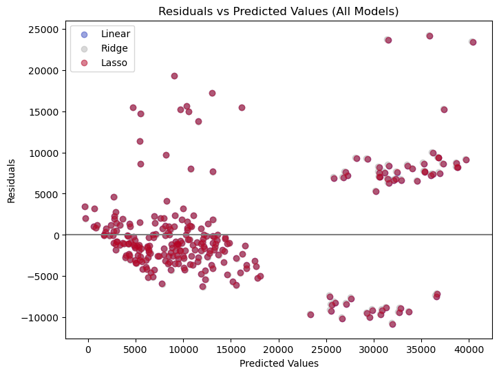

```python
# Predictions
y_pred_lin = baseline_model.predict(X_test)
y_pred_ridge = ridge_model.predict(X_test)
y_pred_lasso = lasso_model.predict(X_test)

# Residuals
res_lin = y_test - y_pred_lin
res_ridge = y_test - y_pred_ridge
res_lasso = y_test - y_pred_lasso

# Diverging colors from a standard palette
colors = ["#3B4CC0", "#B5B5B5", "#B40426"]  # blue → grey → red

plt.figure(figsize=(8,6))
plt.scatter(y_pred_lin, res_lin, alpha=0.5, color=colors[0], label="Linear")
plt.scatter(y_pred_ridge, res_ridge, alpha=0.5, color=colors[1], label="Ridge")
plt.scatter(y_pred_lasso, res_lasso, alpha=0.5, color=colors[2], label="Lasso")

plt.axhline(0, color='grey')
plt.xlabel("Predicted Values")
plt.ylabel("Residuals")
plt.title("Residuals vs Predicted Values (All Models)")
plt.legend()
plt.show()
```

Finally, the validated models are trained on the training data and predictions are made on the test set.

```python
# Final model training on the entire training set
baseline_model.fit(X_train, y_train)
ridge_model.fit(X_train, y_train)
lasso_model.fit(X_train, y_train)

# Predictions on the test set
y_pred_baseline = baseline_model.predict(X_test)
y_pred_ridge = ridge_model.predict(X_test)
y_pred_lasso = lasso_model.predict(X_test)

# Show first 10 predictions for each model
print("Baseline Model Predictions:", y_pred_baseline[:10])
print("Ridge Model Predictions:", y_pred_ridge[:10])
print("Lasso Model Predictions:", y_pred_lasso[:10])

# Evaluate all models
mse_baseline = mean_squared_error(y_test, y_pred_baseline)
r2_baseline = r2_score(y_test, y_pred_baseline)
print(f"Baseline Linear Regression Model - MSE: {mse_baseline:.2f}, R²: {r2_baseline:.2f}")

mse_ridge = mean_squared_error(y_test, y_pred_ridge)
r2_ridge = r2_score(y_test, y_pred_ridge)
print(f"Ridge Linear Regression Model - MSE: {mse_ridge:.2f}, R²: {r2_ridge:.2f}")

mse_lasso = mean_squared_error(y_test, y_pred_lasso)
r2_lasso = r2_score(y_test, y_pred_lasso)
print(f"Lasso Linear Regression Model - MSE: {mse_lasso:.2f}, R²: {r2_lasso:.2f}")
```

```
Baseline Model Predictions: [ 8386.86073797  4377.94975126 13207.96137289 30561.43492101
  8698.81097505 12962.32855148 29328.24830241  2218.81911151
 10966.39979587 10271.05638641]
Ridge Model Predictions: [ 8418.64590989  4402.48784717 13227.6037824  30458.14605774
  8730.07482282 12991.36541772 29216.26772522  2244.5242447
 10987.24020306 10301.70979524]
Lasso Model Predictions: [ 8387.24892798  4377.88292908 13207.83295396 30561.09706576
  8699.12647642 12962.64201509 29327.4551645   2218.76126567
 10966.27794433 10271.4138038 ]
Baseline Linear Regression Model - MSE: 35833764.89, R²: 0.80
Ridge Linear Regression Model - MSE: 36003429.81, R²: 0.80
Lasso Linear Regression Model - MSE: 35834592.31, R²: 0.80
```

## Task 3. Analysis and Interpretation

```python
# Table to compare model performances
model_performance = pd.DataFrame({
    'Model': ['Baseline Linear Regression', 'Ridge Regression', 'Lasso Regression'],
    'Mean Squared Error': [mse_baseline, mse_ridge, mse_lasso],
    'R^2 Score': [r2_baseline, r2_ridge, r2_lasso]
})
print(model_performance)
```

```
                        Model  Mean Squared Error  R^2 Score
0  Baseline Linear Regression        3.583376e+07   0.804993
1            Ridge Regression        3.600343e+07   0.804069
2            Lasso Regression        3.583459e+07   0.804988
```

Earlier in the analysis it was determined that smoker status is the strongest predictor of healthcare costs, and the model coefficients reinforce this conclusion. Across all three regression models, the smoker coefficient is consistently around $23,000, indicating a substantial increase in predicted charges for smokers compared to non‑smokers. In contrast, age and BMI have much smaller positive effects, and sex contributes very little, which aligns with their weaker correlations with the target. These results make sense given known cost drivers in healthcare and support smoking is a significant factor in determining healthcare costs.

```python
# Baseline Linear Regression coefficients
print("Baseline Coefficients:")
print(pd.Series(baseline_model.coef_, index=X.columns))

# Ridge Regression coefficients
print("\nRidge Coefficients:")
print(pd.Series(ridge_model.coef_, index=X.columns))

# Lasso Regression coefficients
print("\nLasso Coefficients:")
print(pd.Series(lasso_model.coef_, index=X.columns))
```

```
Baseline Coefficients:
age         251.779696
bmi         305.132899
sex         -85.347940
smoker    23083.155540
dtype: float64

Ridge Coefficients:
age         251.647014
bmi         304.949617
sex         -76.012655
smoker    22947.869703
dtype: float64

Lasso Coefficients:
age         251.779339
bmi         305.127915
sex         -84.901165
smoker    23082.482250
dtype: float64
```

## Conclusions

These predictions have real‑world value for healthcare cost management because they highlight which patient groups drive spending. Smoking status remains the strongest predictor, but age also plays a meaningful role. The dataset shows that the largest portion of patients fall into the 25–44 age group (531), followed by 45–59 (415), 18–24 (277), and 60+ (114). Understanding both the size of each age group and the model’s finding that charges increase by roughly $250 per year of age can help healthcare organizations anticipate where costs are likely to increase. This allows providers to target interventions or allocate more resources that reflect the actual distribution of their patient population.

## References

Choi, M. (2016). Medical Cost Personal Datasets [Data set]. Kaggle. https://www.kaggle.com/datasets/mirichoi0218/insurance

HealthXWire. (2025). WHO categories of age: Understanding global health definitions. https://wis.it.com/who-categories-of-age-global-health-definitions

James, G., Witten, D., Hastie, T., Tibshirani, R., Taylor, J., & Guo, W. (2023). An introduction to statistical learning: With applications in Python. Springer.

Koivunen-Niemi, L., & K. (2022). Learn best practices for color use in data visualization with python and data from our world in data (2018). In Sage Research Methods: Data Visualization. SAGE Publications, Ltd. https://doi.org/10.4135/9781529605198

Microsoft. (2024). Copilot [Large language model]. Microsoft. https://copilot.microsoft.com [^1]: Copilot was used only for debugging code and refining wording; all analysis and modeling were performed independently.